# Figure 4: MIC60 and ATP synthase copy numbers

# Fig 4D

MIC60 copy number in juxtaspinal and non-juxtaspinal mitochondrial regions measured by DNA-PAINT.

**update for 2026 pending** — The non-juxtaspinal treatment comparison gives p ≈ 0.779. The v3 legend reports p = 0.999.

**Source data**  
`Fig 4 D, E juxta.csv`, `Fig 4 D, E nonjuxta.csv`

**Columns**

- `Date` — Experiment date
- `Condition` — Control or TTX
- `Dish` — Culture dish ID
- `Cell` — Cell ID
- `dendrite` — Dendrite ID
- `spine` — Spine ID
- `probe02` — MIC60 copy count
- `non_juxta` — Non-juxtaspinal region ID

## Data

The input file identifies the region type.

```r
condition_order <- c("Control", "TTX")
region_order <- c("Juxta", "Non Juxta")
group_order <- c("Juxta Control", "Juxta TTX", "Non Juxta Control", "Non Juxta TTX")
spacing_map <- c("Juxta Control" = 1, "Juxta TTX" = 2.2,
                 "Non Juxta Control" = 3.8, "Non Juxta TTX" = 5)

juxta_mic60 <- read_csv("./Fig 4 D, E juxta.csv", show_col_types = FALSE) %>%
  transmute(Date = trimws(as.character(Date)), Condition = trimws(Condition),
            Dish = as.integer(parse_number(as.character(Dish))),
            Cell = as.integer(parse_number(as.character(Cell))),
            dendrite = as.integer(dendrite), mito = as.integer(spine),
            Region = "Juxta", Mic60 = as.numeric(probe02))

nonjuxta_mic60 <- read_csv("./Fig 4 D, E nonjuxta.csv", show_col_types = FALSE) %>%
  transmute(Date = trimws(as.character(Date)), Condition = trimws(Condition),
            Dish = as.integer(parse_number(as.character(Dish))),
            Cell = as.integer(parse_number(as.character(Cell))),
            dendrite = as.integer(dendrite), mito = as.integer(non_juxta),
            Region = "Non Juxta", Mic60 = as.numeric(probe02))

Mic60_df <- bind_rows(juxta_mic60, nonjuxta_mic60) %>%
  filter(Condition %in% condition_order, Date != "", is.finite(Mic60)) %>%
  mutate(Date = factor(Date), Condition = factor(Condition, levels = condition_order),
         Region = factor(Region, levels = region_order),
         Group = factor(paste(Region, Condition), levels = group_order),
         x_pos = unname(spacing_map[as.character(Group)]),
         Group_Date = paste(Group, Date, sep = "_"))
if (!nrow(Mic60_df)) stop("No valid Mic60 measurements remain.")
Mic60_df %>% mutate(across(where(is.numeric), ~ round(.x, 3)))
```

| Date | Condition | Dish | Cell | dendrite | mito | Region | Mic60 | Group | x_pos | Group_Date |
| --- | --- | --- | --- | --- | --- | --- | --- | --- | --- | --- |
| 2026-01-08 | Control | 1 | 1 | 1 | 1 | Juxta | 13 | Juxta Control | 1.0 | Juxta Control_2026-01-08 |
| 2026-01-08 | Control | 1 | 1 | 1 | 2 | Juxta | 6 | Juxta Control | 1.0 | Juxta Control_2026-01-08 |
| 2026-01-08 | Control | 1 | 1 | 1 | 3 | Juxta | 11 | Juxta Control | 1.0 | Juxta Control_2026-01-08 |
| 2026-01-08 | Control | 1 | 1 | 1 | 4 | Juxta | 4 | Juxta Control | 1.0 | Juxta Control_2026-01-08 |
| 2026-01-08 | Control | 1 | 1 | 1 | 5 | Juxta | 1 | Juxta Control | 1.0 | Juxta Control_2026-01-08 |
| 2026-01-08 | Control | 1 | 1 | 1 | 6 | Juxta | 4 | Juxta Control | 1.0 | Juxta Control_2026-01-08 |
| 2026-01-08 | Control | 1 | 1 | 1 | 7 | Juxta | 10 | Juxta Control | 1.0 | Juxta Control_2026-01-08 |
| 2026-01-08 | Control | 1 | 1 | 1 | 8 | Juxta | 14 | Juxta Control | 1.0 | Juxta Control_2026-01-08 |
| 2026-01-08 | Control | 1 | 1 | 1 | 9 | Juxta | 6 | Juxta Control | 1.0 | Juxta Control_2026-01-08 |
| 2026-01-08 | Control | 1 | 1 | 1 | 10 | Juxta | 0 | Juxta Control | 1.0 | Juxta Control_2026-01-08 |

[output cut: 412 more lines]

## Summary

```r
summary_table <- Mic60_df %>% group_by(Group) %>%
  summarise(n_Mitochondria = n_distinct(Date, Dish, Cell, dendrite, mito),
            n_Dendrites = n_distinct(Date, Dish, Cell, dendrite),
            n_Cells = n_distinct(Date, Dish, Cell), n_Experiment_Dates = n_distinct(Date),
            `Mean (SE)` = sprintf("%.3f (%.3f)", mean(Mic60),
                                  sd(Mic60) / sqrt(n())), .groups = "drop")
summary_table
```

| Group | n_Mitochondria | n_Dendrites | n_Cells | n_Experiment_Dates | Mean (SE) |
| --- | --- | --- | --- | --- | --- |
| Juxta Control | 159 | 30 | 23 | 3 | 21.384 (1.064) |
| Juxta TTX | 153 | 31 | 22 | 3 | 32.137 (1.664) |
| Non Juxta Control | 60 | 29 | 21 | 3 | 21.933 (1.479) |
| Non Juxta TTX | 50 | 24 | 20 | 3 | 22.380 (2.044) |

## Statistics

Three-way ANOVA with condition, region, experiment date, and their interactions (Type I sums of squares). Pairwise comparisons use Tukey adjustment.

```r
format_p <- function(p) ifelse(p < 0.0001, "<0.0001", sprintf("%.4f", p))
fit_aov <- aov(Mic60 ~ Condition * Region * Date, data = Mic60_df)
aov_tab <- anova(fit_aov)
anova_table <- as.data.frame(aov_tab) %>% tibble::rownames_to_column("Effect") %>%
  filter(trimws(Effect) != "Residuals") %>%
  transmute(Effect = dplyr::recode(trimws(Effect), Condition = "Condition",
                                   Region = "Region", Date = "Date",
                                   `Condition:Region` = "Condition x Region",
                                   `Condition:Date` = "Condition x Date",
                                   `Region:Date` = "Region x Date",
                                   `Condition:Region:Date` = "Condition x Region x Date"),
            df = Df, F = round(`F value`, 3), `p value` = format_p(`Pr(>F)`))
anova_table
```

| Effect | df | F | p value |
| --- | --- | --- | --- |
| Condition | 1 | 37.857 | <0.0001 |
| Region | 1 | 7.773 | 0.0055 |
| Date | 2 | 63.942 | <0.0001 |
| Condition x Region | 1 | 17.547 | <0.0001 |
| Condition x Date | 2 | 19.120 | <0.0001 |
| Region x Date | 2 | 1.989 | 0.1382 |
| Condition x Region x Date | 2 | 2.967 | 0.0526 |

```r
cell_emm <- emmeans::emmeans(fit_aov, ~ Region * Condition)
all_pairs <- as.data.frame(emmeans::contrast(cell_emm, "pairwise", adjust = "tukey"))
pair_parts <- strsplit(as.character(all_pairs$contrast), " - ", fixed = TRUE)
pair_key <- function(x, y) paste(sort(c(x, y)), collapse = "|")
all_pairs <- all_pairs %>%
  mutate(group1 = vapply(pair_parts, `[`, character(1), 1),
         group2 = vapply(pair_parts, `[`, character(1), 2),
         pair = mapply(pair_key, group1, group2))

comparison_results <- tibble(
  group1 = c("Juxta Control", "Non Juxta Control", "Juxta Control", "Juxta TTX"),
  group2 = c("Juxta TTX", "Non Juxta TTX", "Non Juxta Control", "Non Juxta TTX")
) %>%
  mutate(pair = mapply(pair_key, group1, group2)) %>%
  left_join(all_pairs %>% select(pair, p_value = p.value), by = "pair") %>%
  select(-pair)

group_means <- Mic60_df %>% group_by(Group) %>%
  summarise(mean = mean(Mic60), SE = sd(Mic60) / sqrt(n()), .groups = "drop")
stats_table <- comparison_results %>%
  left_join(group_means, by = c("group1" = "Group")) %>% rename(mean1 = mean, SE1 = SE) %>%
  left_join(group_means, by = c("group2" = "Group")) %>% rename(mean2 = mean, SE2 = SE) %>%
  transmute(Test = "Three-way ANOVA with Tukey post hoc",
            Comparison = paste(group1, "vs", group2),
            `Group 1 mean (SE)` = sprintf("%.3f (%.3f)", mean1, SE1),
            `Group 2 mean (SE)` = sprintf("%.3f (%.3f)", mean2, SE2),
            `Condition p` = format_p(aov_tab["Condition", "Pr(>F)"]),
            `Region p` = format_p(aov_tab["Region", "Pr(>F)"]),
            `Condition x Region p` = format_p(aov_tab["Condition:Region", "Pr(>F)"]),
            `Tukey p` = format_p(p_value))
stats_table
```

| Test | Comparison | Group 1 mean (SE) | Group 2 mean (SE) | Condition p | Region p | Condition x Region p | Tukey p |
| --- | --- | --- | --- | --- | --- | --- | --- |
| Three-way ANOVA with Tukey post hoc | Juxta Control vs Juxta TTX | 21.384 (1.064) | 32.137 (1.664) | <0.0001 | 0.0055 | <0.0001 | <0.0001 |
| Three-way ANOVA with Tukey post hoc | Non Juxta Control vs Non Juxta TTX | 21.933 (1.479) | 22.380 (2.044) | <0.0001 | 0.0055 | <0.0001 | 0.7789 |
| Three-way ANOVA with Tukey post hoc | Juxta Control vs Non Juxta Control | 21.384 (1.064) | 21.933 (1.479) | <0.0001 | 0.0055 | <0.0001 | 0.9993 |
| Three-way ANOVA with Tukey post hoc | Juxta TTX vs Non Juxta TTX | 32.137 (1.664) | 22.380 (2.044) | <0.0001 | 0.0055 | <0.0001 | <0.0001 |

## Plot

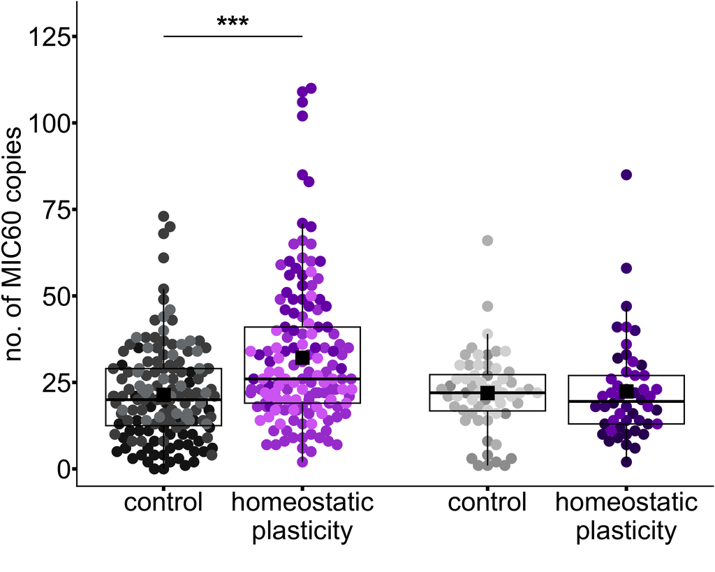

```r
set.seed(20261109)
p_to_stars <- function(p) case_when(p < 0.001 ~ "***", p < 0.01 ~ "**",
                                    p < 0.05 ~ "*", TRUE ~ "ns")
test_results <- comparison_results %>%
  filter(group1 == "Juxta Control", group2 == "Juxta TTX") %>%
  mutate(group1_x = unname(spacing_map[group1]), group2_x = unname(spacing_map[group2]),
         y_position = 125, stars = p_to_stars(p_value)) %>% filter(stars != "ns")

date_levels <- levels(Mic60_df$Date)
group_date_colors <- c(
  setNames(rep(c("#1A1A1A", "#4D4D4D", "#777B7E"), length.out = length(date_levels)),
           paste("Juxta Control", date_levels, sep = "_")),
  setNames(rep(c("#A949D5", "#7A20B5", "#D871F5"), length.out = length(date_levels)),
           paste("Juxta TTX", date_levels, sep = "_")),
  setNames(rep(c("#9E9E9E", "#BDBDBD", "#D9D9D9"), length.out = length(date_levels)),
           paste("Non Juxta Control", date_levels, sep = "_")),
  setNames(rep(c("#350060", "#4B0082", "#7A20B5"), length.out = length(date_levels)),
           paste("Non Juxta TTX", date_levels, sep = "_"))
)

fig4d_plot <- ggplot(Mic60_df, aes(x_pos, Mic60, color = Group_Date)) +
  ggbeeswarm::geom_beeswarm(cex = 2, priority = "random", size = 15, corral = "random") +
  geom_boxplot(aes(group = x_pos), fill = NA, width = 1, linewidth = 2,
               outlier.shape = NA, color = "black") +
  stat_summary(aes(group = x_pos), fun = mean, geom = "point",
               shape = 15, size = 20, color = "black") +
  geom_segment(data = test_results,
               aes(x = group1_x, xend = group2_x, y = y_position, yend = y_position),
               inherit.aes = FALSE, linewidth = 2, color = "black") +
  geom_text(data = test_results,
            aes(x = (group1_x + group2_x) / 2, y = y_position + 3, label = stars),
            inherit.aes = FALSE, size = 30, color = "black", fontface = "bold") +
  scale_x_continuous(breaks = unname(spacing_map),
                     labels = c("control", "homeostatic\nplasticity",
                                "control", "homeostatic\nplasticity")) +
  scale_color_manual(values = group_date_colors) +
  scale_y_continuous(oob = scales::oob_keep, breaks = c(0, 25, 50, 75, 100, 125),
                     limits = c(-5, 135), expand = c(0, 0)) +
  labs(x = "", y = "no. of MIC60 copies") +
  theme_classic() +
  theme(axis.title = element_text(size = 80, color = "black"),
        axis.text = element_text(size = 80, color = "black"),
        axis.ticks = element_line(linewidth = 5, color = "black"),
        axis.ticks.length = grid::unit(0.5, "cm"),
        axis.line = element_line(linewidth = 2, color = "black"),
        legend.position = "none")
fig4d_plot
```

# Fig 4E

ATP synthase copy number in juxtaspinal and non-juxtaspinal mitochondrial regions measured by DNA-PAINT.

**Source data**  
`Fig 4 D, E juxta.csv`, `Fig 4 D, E nonjuxta.csv`

**Columns**

- `Date` — Experiment date
- `Condition` — Control or TTX
- `Dish` — Culture dish ID
- `Cell` — Cell ID
- `dendrite` — Dendrite ID
- `spine` — Spine ID
- `probe01` — ATP synthase copy count
- `non_juxta` — Non-juxtaspinal region ID

## Data

The input file identifies the region type.

```r
condition_order <- c("Control", "TTX")
region_order <- c("Juxta", "Non Juxta")
group_order <- c("Juxta Control", "Juxta TTX", "Non Juxta Control", "Non Juxta TTX")
spacing_map <- c("Juxta Control" = 1, "Juxta TTX" = 2.2,
                 "Non Juxta Control" = 3.8, "Non Juxta TTX" = 5)

juxta_atp <- read_csv("./Fig 4 D, E juxta.csv", show_col_types = FALSE) %>%
  transmute(Date = trimws(as.character(Date)), Condition = trimws(Condition),
            Dish = as.integer(parse_number(as.character(Dish))),
            Cell = as.integer(parse_number(as.character(Cell))),
            dendrite = as.integer(dendrite), mito = as.integer(spine),
            Region = "Juxta", ATP_synthase = as.numeric(probe01))

nonjuxta_atp <- read_csv("./Fig 4 D, E nonjuxta.csv", show_col_types = FALSE) %>%
  transmute(Date = trimws(as.character(Date)), Condition = trimws(Condition),
            Dish = as.integer(parse_number(as.character(Dish))),
            Cell = as.integer(parse_number(as.character(Cell))),
            dendrite = as.integer(dendrite), mito = as.integer(non_juxta),
            Region = "Non Juxta", ATP_synthase = as.numeric(probe01))

ATP_df <- bind_rows(juxta_atp, nonjuxta_atp) %>%
  filter(Condition %in% condition_order, Date != "", is.finite(ATP_synthase)) %>%
  mutate(Date = factor(Date), Condition = factor(Condition, levels = condition_order),
         Region = factor(Region, levels = region_order),
         Group = factor(paste(Region, Condition), levels = group_order),
         x_pos = unname(spacing_map[as.character(Group)]),
         Group_Date = paste(Group, Date, sep = "_"))
if (!nrow(ATP_df)) stop("No valid ATP synthase measurements remain.")
ATP_df %>% mutate(across(where(is.numeric), ~ round(.x, 3)))
```

| Date | Condition | Dish | Cell | dendrite | mito | Region | ATP_synthase | Group | x_pos | Group_Date |
| --- | --- | --- | --- | --- | --- | --- | --- | --- | --- | --- |
| 2026-01-08 | Control | 1 | 1 | 1 | 1 | Juxta | 26 | Juxta Control | 1.0 | Juxta Control_2026-01-08 |
| 2026-01-08 | Control | 1 | 1 | 1 | 2 | Juxta | 68 | Juxta Control | 1.0 | Juxta Control_2026-01-08 |
| 2026-01-08 | Control | 1 | 1 | 1 | 3 | Juxta | 73 | Juxta Control | 1.0 | Juxta Control_2026-01-08 |
| 2026-01-08 | Control | 1 | 1 | 1 | 4 | Juxta | 44 | Juxta Control | 1.0 | Juxta Control_2026-01-08 |
| 2026-01-08 | Control | 1 | 1 | 1 | 5 | Juxta | 1 | Juxta Control | 1.0 | Juxta Control_2026-01-08 |
| 2026-01-08 | Control | 1 | 1 | 1 | 6 | Juxta | 29 | Juxta Control | 1.0 | Juxta Control_2026-01-08 |
| 2026-01-08 | Control | 1 | 1 | 1 | 7 | Juxta | 54 | Juxta Control | 1.0 | Juxta Control_2026-01-08 |
| 2026-01-08 | Control | 1 | 1 | 1 | 8 | Juxta | 91 | Juxta Control | 1.0 | Juxta Control_2026-01-08 |
| 2026-01-08 | Control | 1 | 1 | 1 | 9 | Juxta | 34 | Juxta Control | 1.0 | Juxta Control_2026-01-08 |
| 2026-01-08 | Control | 1 | 1 | 1 | 10 | Juxta | 8 | Juxta Control | 1.0 | Juxta Control_2026-01-08 |

[output cut: 412 more lines]

## Summary

```r
summary_table <- ATP_df %>% group_by(Group) %>%
  summarise(n_Mitochondria = n_distinct(Date, Dish, Cell, dendrite, mito),
            n_Dendrites = n_distinct(Date, Dish, Cell, dendrite),
            n_Cells = n_distinct(Date, Dish, Cell), n_Experiment_Dates = n_distinct(Date),
            `Mean (SE)` = sprintf("%.3f (%.3f)", mean(ATP_synthase),
                                  sd(ATP_synthase) / sqrt(n())), .groups = "drop")
summary_table
```

| Group | n_Mitochondria | n_Dendrites | n_Cells | n_Experiment_Dates | Mean (SE) |
| --- | --- | --- | --- | --- | --- |
| Juxta Control | 159 | 30 | 23 | 3 | 29.226 (1.983) |
| Juxta TTX | 153 | 31 | 22 | 3 | 46.229 (2.340) |
| Non Juxta Control | 60 | 29 | 21 | 3 | 29.750 (2.355) |
| Non Juxta TTX | 50 | 24 | 20 | 3 | 34.500 (2.741) |

## Statistics

Three-way ANOVA with condition, region, experiment date, and their interactions (Type I sums of squares). Pairwise comparisons use Tukey adjustment.

```r
format_p <- function(p) ifelse(p < 0.0001, "<0.0001", sprintf("%.4f", p))
fit_aov <- aov(ATP_synthase ~ Condition * Region * Date, data = ATP_df)
aov_tab <- anova(fit_aov)
anova_table <- as.data.frame(aov_tab) %>% tibble::rownames_to_column("Effect") %>%
  filter(trimws(Effect) != "Residuals") %>%
  transmute(Effect = dplyr::recode(trimws(Effect), Condition = "Condition",
                                   Region = "Region", Date = "Date",
                                   `Condition:Region` = "Condition x Region",
                                   `Condition:Date` = "Condition x Date",
                                   `Region:Date` = "Region x Date",
                                   `Condition:Region:Date` = "Condition x Region x Date"),
            df = Df, F = round(`F value`, 3), `p value` = format_p(`Pr(>F)`))
anova_table
```

| Effect | df | F | p value |
| --- | --- | --- | --- |
| Condition | 1 | 60.144 | <0.0001 |
| Region | 1 | 6.327 | 0.0123 |
| Date | 2 | 180.601 | <0.0001 |
| Condition x Region | 1 | 2.470 | 0.1168 |
| Condition x Date | 2 | 1.597 | 0.2037 |
| Region x Date | 2 | 2.152 | 0.1176 |
| Condition x Region x Date | 2 | 0.330 | 0.7192 |

```r
cell_emm <- emmeans::emmeans(fit_aov, ~ Region * Condition)
all_pairs <- as.data.frame(emmeans::contrast(cell_emm, "pairwise", adjust = "tukey"))
pair_parts <- strsplit(as.character(all_pairs$contrast), " - ", fixed = TRUE)
pair_key <- function(x, y) paste(sort(c(x, y)), collapse = "|")
all_pairs <- all_pairs %>%
  mutate(group1 = vapply(pair_parts, `[`, character(1), 1),
         group2 = vapply(pair_parts, `[`, character(1), 2),
         pair = mapply(pair_key, group1, group2))

comparison_results <- tibble(
  group1 = c("Juxta Control", "Non Juxta Control", "Juxta Control", "Juxta TTX"),
  group2 = c("Juxta TTX", "Non Juxta TTX", "Non Juxta Control", "Non Juxta TTX")
) %>%
  mutate(pair = mapply(pair_key, group1, group2)) %>%
  left_join(all_pairs %>% select(pair, p_value = p.value), by = "pair") %>%
  select(-pair)

group_means <- ATP_df %>% group_by(Group) %>%
  summarise(mean = mean(ATP_synthase), SE = sd(ATP_synthase) / sqrt(n()), .groups = "drop")
stats_table <- comparison_results %>%
  left_join(group_means, by = c("group1" = "Group")) %>% rename(mean1 = mean, SE1 = SE) %>%
  left_join(group_means, by = c("group2" = "Group")) %>% rename(mean2 = mean, SE2 = SE) %>%
  transmute(Test = "Three-way ANOVA with Tukey post hoc",
            Comparison = paste(group1, "vs", group2),
            `Group 1 mean (SE)` = sprintf("%.3f (%.3f)", mean1, SE1),
            `Group 2 mean (SE)` = sprintf("%.3f (%.3f)", mean2, SE2),
            `Condition p` = format_p(aov_tab["Condition", "Pr(>F)"]),
            `Region p` = format_p(aov_tab["Region", "Pr(>F)"]),
            `Condition x Region p` = format_p(aov_tab["Condition:Region", "Pr(>F)"]),
            `Tukey p` = format_p(p_value))
stats_table
```

| Test | Comparison | Group 1 mean (SE) | Group 2 mean (SE) | Condition p | Region p | Condition x Region p | Tukey p |
| --- | --- | --- | --- | --- | --- | --- | --- |
| Three-way ANOVA with Tukey post hoc | Juxta Control vs Juxta TTX | 29.226 (1.983) | 46.229 (2.340) | <0.0001 | 0.0123 | 0.1168 | 0.0271 |
| Three-way ANOVA with Tukey post hoc | Non Juxta Control vs Non Juxta TTX | 29.750 (2.355) | 34.500 (2.741) | <0.0001 | 0.0123 | 0.1168 | 0.9367 |
| Three-way ANOVA with Tukey post hoc | Juxta Control vs Non Juxta Control | 29.226 (1.983) | 29.750 (2.355) | <0.0001 | 0.0123 | 0.1168 | 0.1029 |
| Three-way ANOVA with Tukey post hoc | Juxta TTX vs Non Juxta TTX | 46.229 (2.340) | 34.500 (2.741) | <0.0001 | 0.0123 | 0.1168 | 0.0029 |

## Plot

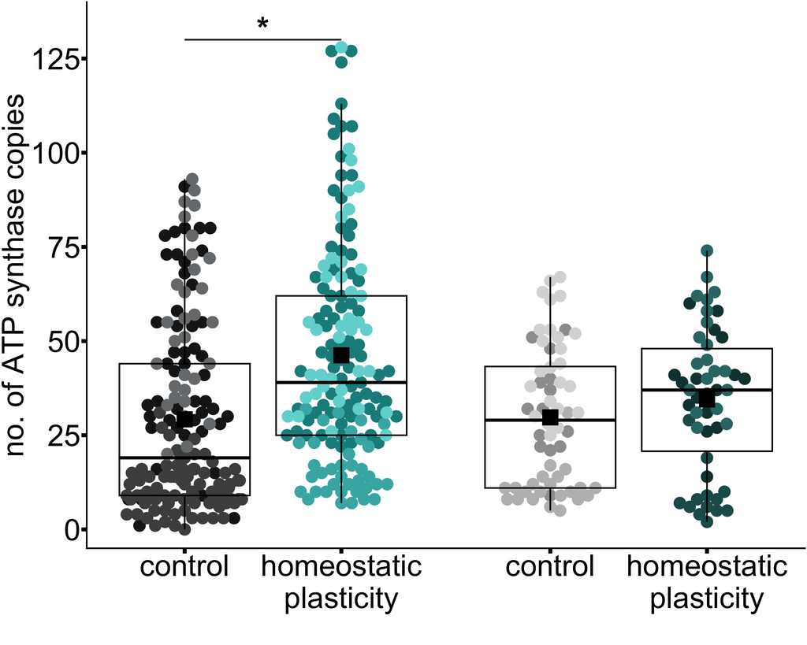

```r
set.seed(20261109)
p_to_stars <- function(p) case_when(p < 0.001 ~ "***", p < 0.01 ~ "**",
                                    p < 0.05 ~ "*", TRUE ~ "ns")
test_results <- comparison_results %>%
  filter(group1 == "Juxta Control", group2 == "Juxta TTX") %>%
  mutate(group1_x = unname(spacing_map[group1]), group2_x = unname(spacing_map[group2]),
         y_position = 130, stars = p_to_stars(p_value)) %>% filter(stars != "ns")

date_levels <- levels(ATP_df$Date)
group_date_colors <- c(
  setNames(rep(c("#1A1A1A", "#4D4D4D", "#777B7E"), length.out = length(date_levels)),
           paste("Juxta Control", date_levels, sep = "_")),
  setNames(rep(c("#168C8B", "#42B3B2", "#70D6D4"), length.out = length(date_levels)),
           paste("Juxta TTX", date_levels, sep = "_")),
  setNames(rep(c("#9E9E9E", "#BDBDBD", "#D9D9D9"), length.out = length(date_levels)),
           paste("Non Juxta Control", date_levels, sep = "_")),
  setNames(rep(c("#123F3F", "#205B5A", "#307675"), length.out = length(date_levels)),
           paste("Non Juxta TTX", date_levels, sep = "_"))
)

fig4e_plot <- ggplot(ATP_df, aes(x_pos, ATP_synthase, color = Group_Date)) +
  ggbeeswarm::geom_beeswarm(cex = 2, priority = "random", size = 15, corral = "random") +
  geom_boxplot(aes(group = x_pos), fill = NA, width = 1, linewidth = 2,
               outlier.shape = NA, color = "black") +
  stat_summary(aes(group = x_pos), fun = mean, geom = "point",
               shape = 15, size = 20, color = "black") +
  geom_segment(data = test_results,
               aes(x = group1_x, xend = group2_x, y = y_position, yend = y_position),
               inherit.aes = FALSE, linewidth = 2, color = "black") +
  geom_text(data = test_results,
            aes(x = (group1_x + group2_x) / 2, y = y_position + 3, label = stars),
            inherit.aes = FALSE, size = 30, color = "black", fontface = "bold") +
  scale_x_continuous(breaks = unname(spacing_map),
                     labels = c("control", "homeostatic\nplasticity",
                                "control", "homeostatic\nplasticity")) +
  scale_color_manual(values = group_date_colors) +
  scale_y_continuous(oob = scales::oob_keep, breaks = c(0, 25, 50, 75, 100, 125),
                     limits = c(-5, 140), expand = c(0, 0)) +
  labs(x = "", y = "no. of ATP synthase copies") +
  theme_classic() +
  theme(axis.title = element_text(size = 80, color = "black"),
        axis.text = element_text(size = 80, color = "black"),
        axis.ticks = element_line(linewidth = 5, color = "black"),
        axis.ticks.length = grid::unit(0.5, "cm"),
        axis.line = element_line(linewidth = 2, color = "black"),
        legend.position = "none")
fig4e_plot
```